# Chapter 2: Deep learning for coders with fastai and pytorch

## Deep Learning In Production

When we create a model that met our objectives, we can then pass to the **Production** phase, where we transform the model into an appliction/service etc..  
But first we need to export the model into a file:

```python
learn.export()
```

Let’s check that the file exists, by using the `ls` method that fastai adds to Python’s `Path` class:

```python
path = Path()
path.ls(file_exts='.pkl')
```

```
(#1) [Path('export.pkl')]
```

- Now with the `export.pkl` file we can create normal program that takes inputs(images) and produce results (predictions) just like any traditional app
- At this point we won’t call it a model anymore, we call it `inference`.

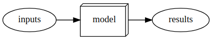

>*Using the trained model as program*

The `export()` function allow us to save the model in oreder to use it later, and as we know model is **Architecture + Parameters**, **Fastai** by default saves also the method of which we’ve created the `DataLoaders`, because otherwise we have to define it again in order to work with the new data we will feed to the model.

### From Model to Inference

This file `export.pkl` is allways needed wherever we will create an app from it, for now we will use it whithin this notebook in order to create a small app that can predict bears type from image we will provide.

When we use a model for getting predictions, instead of training, we call it **inference**.  
To create `inference learner` from `export.pkl` file we use `load_learner`:

```python
learn_inf = load_learner(path/'export.pkl')
```

```python
# predicting one image
learn_inf.predict('images/bear.jpg')
```

```
('grizzly', TensorBase(1), TensorBase([8.0130e-07, 1.0000e+00, 2.0153e-07]))
```

- This has returned three things:
  - the predicted category(label) in the same format we originally provided (in this case that’s a string),
  - the index of the predicted category, and the probabilities of each category.
  - the last two are based on the order of categories in the *vocab* of the `DataLoaders`; that is, the stored list of all possible categories.
- At inference time, you can access the `DataLoaders` as an attribute of the `Learner`:

```python
learn_inf.dls.vocab
```

```
['black', 'grizzly', 'teddy']
```

We can see here that if we index into the vocab with the integer returned by `predict` then we get back “grizzly,” as expected. Also, note that if we index into the list of probabilities, we see a nearly 1.00 probability that this is a grizzly.

### Gradio + HugginFace Spaces

- If we want to share our model with a broader audience, and showcase our skills we need to create a real app that can be used outside of the datascience/machine learning word where nobody know or have the ability to use jupyter notebook or python.. and that’s why we will show using a combination of python package **Gradio** that will allow us to build our app, then host it on **HuggingFace**

```python
# firstly install gradio
!pip install gradio
```

[output not shown]

```python
# create labels from dalaloaders vocab
labels = learn.dls.vocab
# predicting function that take an image as input and use learn.predict to ouput:
# prediction, prediction index, and probability.
def predict(img):
    img = PILImage.create(img)
    pred,pred_idx,probs = learn.predict(img)
    return {labels[i]: float(probs[i]) for i in range(len(labels))}
```

- Here we will use gradio in order to create an app withing this notebook.

```python
import gradio as gr
gr.Interface(fn=predict, inputs=gr.inputs.Image(shape=(512, 512)), outputs=gr.outputs.Label(num_top_classes=3)).launch(share=True)
```

```
Colab notebook detected. To show errors in colab notebook, set `debug=True` in `launch()`
Running on public URL: https://bbc80cb39aa58cc0.gradio.app

This share link expires in 72 hours. For free permanent hosting and GPU upgrades (NEW!), check out Spaces: https://huggingface.co/spaces
```

[interactive chart not shown]

```
(<gradio.routes.App at 0x7f45d2b49710>,
 'http://127.0.0.1:7860/',
 'https://bbc80cb39aa58cc0.gradio.app')
```

- Still the best way of creating app for inference is to use Hugginface platform with help of gradio.
- Here is the app that classify bears types based the `.pkl` file we created from our model we trained: [Here](https://huggingface.co/spaces/Smail/b-Class)